# Regressions for differential analysis

## Are these two groups different? We compare two samples in terms of statistical parameters such as mean, variance, etc.

## **t-test: mean comparison.**

## $\{x_1, x_2, x_3, x_4, \dots, x_{n_1} \}$ is from $N(\mu_1, \sigma_1^2)$ and

## $\{y_1, y_2, y_3, y_4, \dots, y_{n_2} \}$ is from $N(\mu_2, \sigma_2^2)$

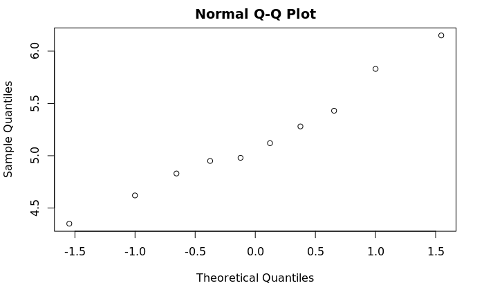

```r
x <- c(5.12, 5.28, 4.98, 4.62, 4.95, 4.35, 4.83, 6.15, 5.83, 5.43)
y <- c(5.37, 5.63, 5.89, 5.92, 5.91, 6.15, 6.29, 6.41, 6.88, 7.12)

qqnorm(x);
```

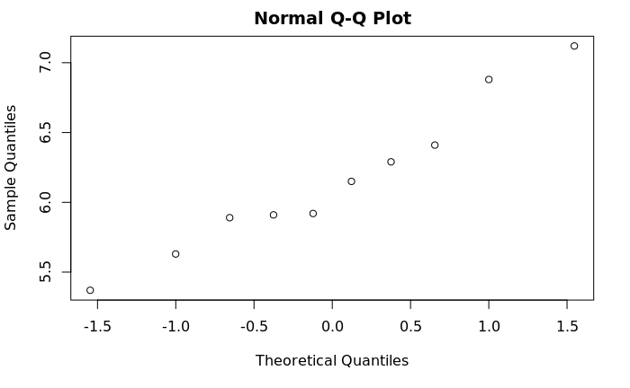

```r
qqnorm(y);
```

```r
ttest.res <- t.test(x,y)
ttest.res$p.value
```

```
[1] 0.0006073053
```

## $t-score = \frac{\bar{x}-\bar{y}}{ \sqrt{ s^2_x/n_1+s^2_y/n_2 } }$

## distribution is $t_{(\nu)}$

## $\nu = \frac{(s^2_x/n_1+s^2_y/n_2)^2}{(s^2_x/n_1)^2/(n_1-1)+(s^2_y/n_2)^2/(n_2-1)}$

# **Linear regression**

## $\hat{y}=\beta_0 + \beta_1 x$

## $\{x_1, x_2, x_3, x_4, \dots, x_{n_1} \}$ is from $N(\beta_0+\beta_1\cdot 0, \sigma^2)$ and

## $\{y_1, y_2, y_3, \dots, y_{n_2} \}$ is from $N(\beta_0+\beta_1\cdot 1, \sigma^2)$

## Since the estimator’s of $\beta_0$ and $\beta_1$ are calculated by using $x_i$ and $y_j$, we also have probability distributions for the estimators of $\beta_0$ and $\beta_1$. $\beta_1$ estimator’s distribution is another $t$-distribution. Using this we can test

## $H_0:\beta_1=0$

## If rejected, $i.e.$, $P-$value is low enough, we can say that means are different.

```r
library(ggplot2)
rm(data_4_lin_reg)
```

```
object 'data_4_lin_reg' not found
```

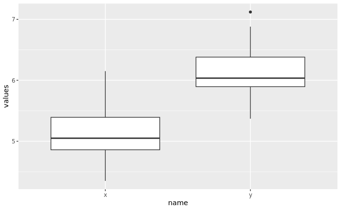

```r
data_4_lin_reg <- data.frame(name = rep("x", length(x)), values = x)
data_4_lin_reg <- rbind(data_4_lin_reg, data.frame(name = rep("y", length(y)), values = y))
ggplot(data = data_4_lin_reg, aes(x=name, y=values))+geom_boxplot()
```

```r
# lin_reg2 <- glm(data = data_4_lin_reg, values ~ name, family=gaussian)
# summary(lin_reg2)
```

```r
var.test(x, y, alternative = "two.sided")
```

```
    F test to compare two variances

data:  x and y
F = 1.0127, num df = 9, denom df = 9, p-value = 0.9853
alternative hypothesis: true ratio of variances is not equal to 1
95 percent confidence interval:
 0.2515393 4.0771072
sample estimates:
ratio of variances
          1.012696
```

```r
lin_reg <- lm(data = data_4_lin_reg, values ~ name)
coef(summary(lin_reg))[2,4]
```

```
[1] 0.0006072601
```

```r
y_1=1.4*y-2.0
```

```r
var.test(x, y_1, alternative = "two.sided")
```

```
    F test to compare two variances

data:  x and y_1
F = 0.51668, num df = 9, denom df = 9, p-value = 0.3395
alternative hypothesis: true ratio of variances is not equal to 1
95 percent confidence interval:
 0.1283364 2.0801567
sample estimates:
ratio of variances
         0.5166815
```

```r
ttest.res <- t.test(x,y_1)
ttest.res$p.value
```

```
[1] 0.0001267858
```

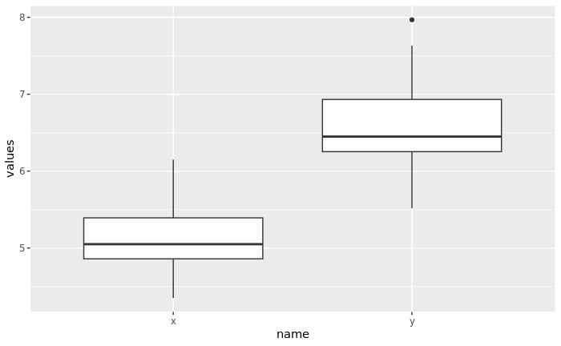

```r
rm(data_4_lin_reg)
data_4_lin_reg <- data.frame(name = rep("x", length(x)), values = x)
data_4_lin_reg <- rbind(data_4_lin_reg, data.frame(name = rep("y", length(y_1)), values = y_1))
#data_4_lin_reg

ggplot(data = data_4_lin_reg, aes(x=name, y=values))+geom_boxplot()
```

```r
lin_reg <- lm(data = data_4_lin_reg, values ~ name)
coef(summary(lin_reg))[2,4]
```

```
[1] 9.585896e-05
```

# **General linear regressions**

## **1. Linear regression.**

## $Y|_{x} \sim N(\beta_0 + \beta_1 x,\sigma)$

## $E(Y|_{x})=\beta_0 +\beta_1 x$

## Probability distribution, $f(y|x;(\beta_0, \beta_1 ))=n(\beta_0 + \beta_1 x,\sigma)$

```r
ind.var <- seq(1, 10, by=1)
dep.var <- ind.var + rnorm(10, 0, 1.5)
```

```r
linreg.res <- lm(data = data.frame(x=ind.var, y= dep.var), y ~ x)
coef(summary(linreg.res))
```

```
              Estimate Std. Error    t value     Pr(>|t|)
(Intercept) -0.2844622  1.0760642 -0.2643543 0.7981897442
x            0.9472229  0.1734235  5.4619079 0.0006001724
```

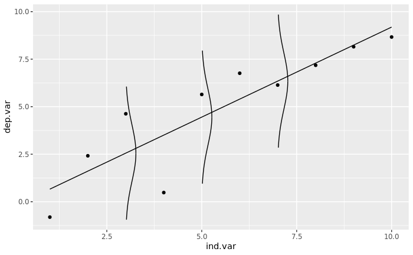

```r
interc = coef(summary(linreg.res))[1,1]; slope = coef(summary(linreg.res))[2,1]

ggplot(data = data.frame(x=ind.var, y= dep.var))+geom_point(aes(x=ind.var, y=dep.var)) +
  geom_line(aes(x=ind.var, y=interc + slope*ind.var   )) +
  geom_line(data = data.frame(x=dnorm(seq(-3.5,0,by=0.01), 0, 1.5)+3,
                              y=seq(-3.5,0,by=0.01)+interc + slope*3), aes(x=x, y= y  )) +
  geom_line(data = data.frame(x=dnorm(seq(0,3.5,by=0.01), 0, 1.5)+3,
                              y=seq(0,3.5,by=0.01)+interc + slope*3), aes(x=x, y= y  )) +
  geom_line(data = data.frame(x=dnorm(seq(-3.5,0,by=0.01), 0, 1.5)+5,
                              y=seq(-3.5,0,by=0.01)+interc + slope*5), aes(x=x, y= y  )) +
  geom_line(data = data.frame(x=dnorm(seq(0,3.5,by=0.01), 0, 1.5)+5,
                              y=seq(0,3.5,by=0.01)+interc + slope*5), aes(x=x, y= y  )) +
  geom_line(data = data.frame(x=dnorm(seq(-3.5,0,by=0.01), 0, 1.5)+7,
                              y=seq(-3.5,0,by=0.01)+interc + slope*7), aes(x=x, y= y  )) +
  geom_line(data = data.frame(x=dnorm(seq(0,3.5,by=0.01), 0, 1.5)+7,
                              y=seq(0,3.5,by=0.01)+interc + slope*7), aes(x=x, y= y  ))
```

```r
NA
NA
```

## How to find $\beta_0$ and $\beta_1$.

## Data $\{(x_1, y_1), (x_2, y_2), (x_3, y_3), (x_4, y_4), (x_5, y_5)\}$

### $SSE = F(\beta_0, \beta_1 ) = \sum_1^5 (\beta_0 + \beta_1x_i - y_i)^2$; multivariable (geometry) calculus problem.

### - Maximize likelihood function, $L$

### $L = \prod_1^5 \frac{1}{\sqrt{2\pi}\sigma}\exp(-\frac{(\beta_0 + \beta_1x_i - y_i)^2}{2\sigma^2})$. Or, minimize $-ln(L)$ which is the same as minimizing $SSE$.

### - Solve $X^TX\cdot B=X^TY$

#### $X=\begin{bmatrix} 1 & x_1 \\ 1 & x_2 \\ \vdots & \vdots \\ 1 & x_5 \end{bmatrix}$, $B=\begin{bmatrix} \beta_0 \\ \beta_1 \end{bmatrix}$, $Y=\begin{bmatrix} y_1 \\ y_2 \\ \vdots \\ y_5 \end{bmatrix}$.

```r
linreg.res <- glm(data = data.frame(x=ind.var, y= dep.var), y ~ x, family=gaussian )
coef(summary(linreg.res))
```

```
              Estimate Std. Error    t value     Pr(>|t|)
(Intercept) -0.2844622  1.0760642 -0.2643543 0.7981897442
x            0.9472229  0.1734235  5.4619079 0.0006001724
```

## **2. Logistic regression.**

## $Y|x \sim B(n,p|_x).$ We assume that $E(Y|x) = n\cdot inv.logit(\beta_0 +\beta_1 x)$.

## Since $E(Y|x)=n\cdot p|_x$, $p|_x=inv.logit(\beta_0 +\beta_1 x)$. Or,

## $logit(p|_x)=\beta_0 +\beta_1 x$.

## Logit is called the link function for logistic regression.

## Probability distribution,

### $f(1|x)=p|_x$ and $f(0|x)=1-p|_x$

### $$L=\prod_{y_i=0}(1-p|_{x_i})\cdot \prod_{y_i=1}(p|_{x_i})$$

### $$\ln L = \sum_{i}((1-y_i)\ln (1-p|_{x_i}) + y_i\ln (p|_{x_i}))$$

### $$\left( \frac{\hat{\beta_i}}{s.e.(\hat{\beta_i})} \right)^2 \sim \chi^2$$

```r
library(ggplot2)
ind.var_bin <- seq(-3, 3, by=0.5)
#p <- inv.logit(ind.var_bin)

dep.var_bin <- c(0,0,0,1,0,1,0,1,1,0,1,1,1)

binreg.res <- glm(data = data.frame(x=ind.var_bin, y= dep.var_bin), y ~ x, family=binomial(link=logit) )
coef(summary(binreg.res))
```

```
             Estimate Std. Error   z value   Pr(>|z|)
(Intercept) 0.2331067  0.6881342 0.3387518 0.73479673
x           0.8053177  0.4440151 1.8137168 0.06972133
```

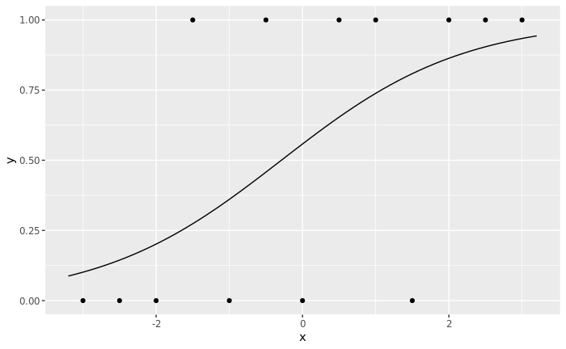

```r
tt=seq(-3.2, 3.2, by = 0.1)
ggplot(data=data.frame(x=ind.var_bin, y=dep.var_bin))+geom_point(aes(x=x,y=y)) +
  geom_line(data=data.frame(x=tt, y=inv.logit(coef(summary(binreg.res))[1,1]+coef(summary(binreg.res))[2,1]*tt)), aes(x=x,y=y))
```

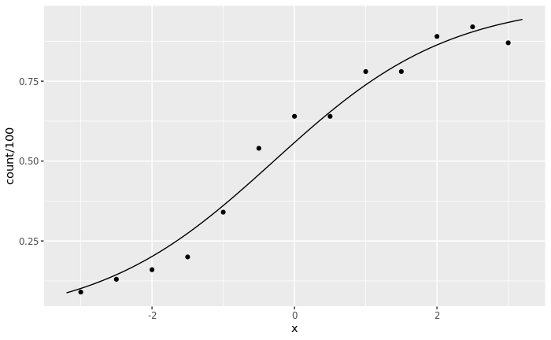

```r
success =  data.frame(count=rep(0, length(ind.var_bin)))
for (ii in (1:length(ind.var_bin))){

  p0 <- inv.logit(coef(summary(binreg.res))[1,1]+coef(summary(binreg.res))[2,1]*ind.var_bin[ii])
  success$count[ii] = rbinom(1,100, p0)

}

ggplot(data = data.frame(x=ind.var_bin, count=success$count)) + geom_point(aes(x=x,y=count/100)) + geom_line(data=data.frame(x=tt, y=inv.logit(coef(summary(binreg.res))[1,1]+coef(summary(binreg.res))[2,1]*tt)), aes(x=x,y=y))
```

```r
#
# x0 <- seq(1:100)/100
# y0 <- 10*dbinom(seq(1:100), 100, p0)
#
# ggplot(data=data.frame(x=x0, y=y0))+geom_point(aes(x=y,y=x), pch=15, size=0.5)

  # geom_line(data = data.frame(x=dbinom(seq(1:100), 100, 1.5)+7,
  #                             y=seq(-3.5,0,by=0.01)+interc + slope*7), aes(x=x, y= y  )) +
  # geom_line(data = data.frame(x=dnorm(seq(0,3.5,by=0.01), 0, 1.5)+7,
  #                             y=seq(0,3.5,by=0.01)+interc + slope*7), aes(x=x, y= y  ))
```

## **3. Poisson regression.**

## $Y|_x \sim Poisson(e^{\beta_0 +\beta_1 x})$

## $E(Y|_x)=e^{\beta_0 +\beta_1 x}$

## $$f(y|_x)=\frac{e^{(\beta_0 +\beta_1 x)y} \exp(-e^{\beta_0 +\beta_1 x})}{y!}$$

### $$\ln L = \sum_{i}\left( (\beta_0+\beta_1 x_i)y_i - e^{\beta_0+\beta_1 x_i} - \ln (y_i!) \right)$$

### $$\ln (E(Y|_x)) = \beta_0 + \beta_1 x.$$ Linear again!!

```r
pois_reg <- glm(data=data, y ~ x, family=poisson)
```

```r
slope=1.5
x=seq(0, 1, by=0.1)
y=rpois(11, exp(1+slope*x))


pois_reg <- glm(data=data.frame(x=x,y=y), y ~ x, family=poisson)
p_slope = coef(summary(pois_reg))[2,1]; p_interc <- coef(summary(pois_reg))[1,1]
coef(summary(pois_reg))
```

```
             Estimate Std. Error  z value     Pr(>|z|)
(Intercept) 0.9086504  0.2974696 3.054599 0.0022536163
x           1.5121244  0.4194391 3.605111 0.0003120198
```

```r
lin_reg <- glm(data=data.frame(x=x,y=y), y ~ x, family=gaussian)
l_slope = coef(summary(lin_reg))[2,1]; l_interc <- coef(summary(lin_reg))[1,1]
coef(summary(lin_reg))
```

```
            Estimate Std. Error  t value   Pr(>|t|)
(Intercept) 1.636364   1.439123 1.137056 0.28488131
x           8.545455   2.432561 3.512945 0.00658806
```

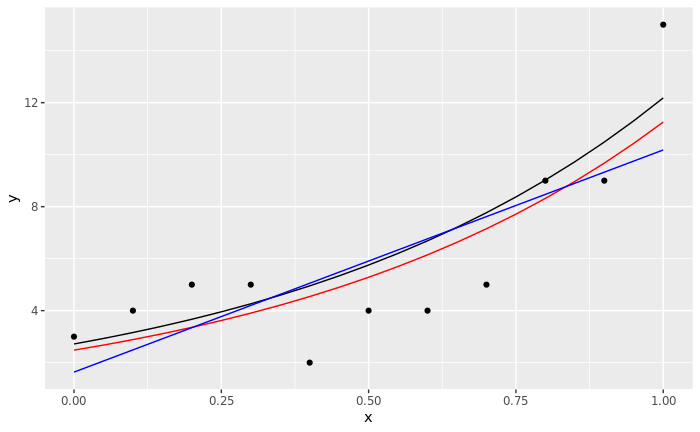

```r
ggplot(data = data.frame(x=x,y=y))+geom_point(aes(x=x,y=y)) +
  geom_line( data=data.frame(x=seq(0, 1, by=0.05), y=exp(1+slope*seq(0, 1, by=0.05)))     , aes(x=x,y=y)) +
  geom_line( data=data.frame(x=seq(0, 1, by=0.05), y=exp(p_interc+p_slope*seq(0, 1, by=0.05))), aes(x=x,y=y), color = "red") +
  geom_line( data=data.frame(x=seq(0, 1, by=0.05), y=l_interc+l_slope*seq(0, 1, by=0.05)), aes(x=x,y=y), color = "blue")
```

```r
NA
NA
NA
```

# **Regressions to compare two groups: P-value calculation.**

## - State marker expression data.

### What’s the population? What is the random variable? Samples?

### Example:

- population of virginia who had heart attack.
- Median of NK$\kappa$B expression from all Treg cells.
- 16 people.

### What is the distribution?

- one side open ended counting data: Poisson, Negative binomial distribution
- data transformed by $\text{asinh}=\ln (x+\sqrt{x^2+1}) \sim \ln 2 + \ln x \text{ for} x>>1$
- Gaussian.

### Use T-test or linear regression

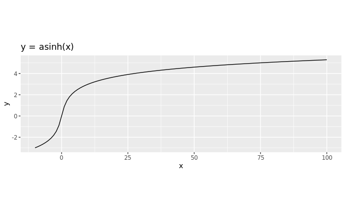

```r
ggplot(data = data.frame(x=seq(-10, 100, by=1), y=asinh(seq(-10, 100, by=1))))+geom_line(aes(x=x,y=y)) + coord_fixed(ratio = 4/1) +
  labs(title = paste("y = asinh(x)"))
```

## - Proportion data. Cluster proportions.

### What is the distribution?

#### - Binomial distribution. **Logistic regression** or Quasi-logistic regression.

#### $$P(x=k)= {n \choose x}p(p+k\phi)^{k-1}(1-p-k\phi)^{n-k}$$

#### - If $X \sim B(n,p)$, $X \sim N(np, npq)$, approximately ($n\geq 15$). Then, **t-test** or linear regression can be applied.

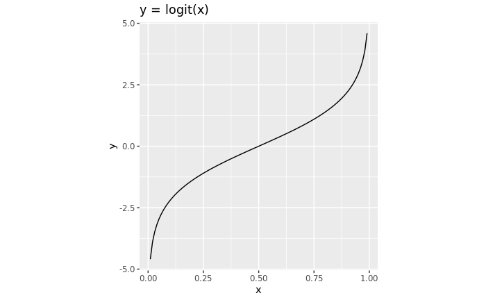

```r
ggplot(data = data.frame(x=seq(0.01,0.99, by=0.01), y=logit( seq(0.01,0.99, by=0.01) )))+geom_line(aes(x=x,y=y)) + coord_fixed(ratio = 1/9) +
  labs(title = paste("y = logit(x)"))
```

#### - $$\ln\left( \frac{proportion}{1-proportion} \right) \sim Gaussian$$ . Apply *t-test or linear regression* to **log odds ratio**.

## Weights

### - Maximize likelihood function, $L$

### $$L = \prod_1^n \left( \frac{1}{\sqrt{2\pi}\sigma}\exp \left(-\frac{(\beta_0 + \beta_1x_i - y_i)^2}{2\sigma^2} \right) \right)^{w_i}.$$

### $$-\ln L = Constant \cdot \sum^n_1w_i (\beta_0 + \beta_1x_i - y_i)^2$$